# The genetics package

Abstract

“The genetics package” published in R News.

## Utilities for handling genetic data

## Introduction

In my work as a statistician in the Non-Clinical Statistics and Biostatistical Applications group within Pfizer Global Research and Development I have the opportunity to perform statistical analysis in a wide variety of domains. One of these domains is pharmacogenomics, in which we attempt to determine the relationship between the genetic variability of individual patients and disease status, disease progression, treatment efficacy, or treatment side effect profile.

Our normal approach to pharmacogenomics is to start with a small set of candidate genes. We then look for markers of genetic variability within these genes. The most common marker types we encounter are Single Nucleotide Polymorphisms (SNPs). SNPs are locations where some individuals differ from the norm by the substitution one of the 4 DNA bases, adenine (A), thymine (T), guanine (G), and cytosine (C), by one of the other bases. For example, a single cytosine (C) might be replaced by a single tyrosine (T) in the sequence ‘CCTCAGC’, yielding ‘CCTTAGC’. We also encounter simple sequence length polymorphisms (SSLP), which are also known as microsatellite DNA. SSLP are simple reteating patters of bases where the number of repeats can vary. E.g., at a particular position, some individuals might have 3 repeats of the pattern ‘CT’, ‘ACCTCTCTAA’, while others might have 5 repeats, ‘ACCTCTCTCTCTAA’.

Regardless of the type or location of genetic variation, each individual has two copies of each chromosome, hence two alleles (variants), and consequently two data values for each marker. This information is often presented together by providing a pair of allele names. Sometimes a separator is used (e.g. ‘A/T’), sometimes they are simply concatenated (e.g., ‘AT’).

A further layer of complexity arises from the inability of most laboratory methods to determine which observed variants comes from which copy of the chromosome. (Statistical methods are often necessary to impute this information when it is needed.) For this type of data ‘A/T’, and ‘T/A’ are equivalent.

## The genetics package

The **genetics** package, available from CRAN, includes classes and methods for creating, representing, and manipulating genotypes (unordered allele pairs) and haplotypes (ordered allele pairs). Genotypes and haplotypes can be annotated with chromosome, locus (location on a chromosome), gene, and marker information. Utility functions compute genotype and allele frequencies, flag homozygotes or heterozygotes, flag carriers of certain alleles, count the number of a specific allele carried by an individual, extract one or both alleles. These functions make it easy to create and use single-locus genetic information in R’s statistical modeling functions.

The **genetics** package also provides a set of functions to estimate and test for departure from Hardy-Weinberg equilibrium (HWE). HWE specifies the expected allele frequencies for a single population when none of the variant alleles impart a survival benefit. Departure from HWE is often indicative of a problem with the laboratory assay, and is often the first statistical method applied to genetic data. In addition, the **genetics** package provides functions to test for linkage disequilibrium (LD), the non-random association of marker alleles which can arise from marker proximity or from selection bias. Further, to assist in sample size calculations when considering sample sizes needed when investigating potential markers, we provide a function which computes the probability of observing all alleles with a given true frequency.

My primary motivation in creating the **genetics** package was to overcome the difficulty in representing and manipulating genotype in general-purpose statistical packages. Without an explicit genotype variable type, handling genetic variables requires considerable string manipulation, which can be quite messy and tedious. The genotype function has been designed to remove the need to perform string manipulation by allowing allele pairs to be specified in any of four commonly occuring notations:

- A single vector with a character separator:

```
g1 <- genotype( c('A/A', 'A/C', 'C/C', 'C/A',
                  NA, 'A/A', 'A/C', 'A/C') )
g3 <- genotype( c('A A', 'A C', 'C C', 'C A',
                  '', 'A A', 'A C', 'A C'),
                sep= ' ', remove.spaces=F)
```

- A single vector with a positional separator

```
g2 <- genotype( c('AA', 'AC', 'CC', 'CA', '',
                  'AA', 'AC', 'AC'), sep=1 )
```

- Two separate vectors

```
g4 <- genotype(
  c('A', 'A', 'C', 'C', '', 'A', 'A', 'A'),
  c('A', 'C', 'C', 'A', '', 'A', 'C', 'C')
)
```

- A dataframe or matrix with two columns

```
gm <- cbind(
  c('A', 'A', 'C', 'C', '', 'A', 'A', 'A'),
  c('A', 'C', 'C', 'A', '', 'A', 'C', 'C') )
g5 <- genotype( gm )
```

For simplicity, the functions `makeGenotype` and `makeHaplotype` can be used to convert all of the genetic variables contained in a dataframe in a single pass. (See the help page for details.)

A second difficulty in using genotypes is the need to represent the information in different forms at different times. To simplify the use of genotype variables, each of the three basic ways of modeling the effect of the allele combinations is directly supported by the **genetics** package:

**categorical** Each allele combination acts differently.

This situation is handled by entering the genotype variable without modification into a model. In this case, it will be treated as a factor:

```
lm( outcome ~ genotype.var + confounder )
```

**additive** The effect depends on the number of copies of a specific allele (0, 1, or 2).

The function `allele.count( gene, allele )` returns the number of copies of the specified allele:

```
lm( outcome ~ allele.count(genotype.var, 'A')
+ confounder )
```

**dominant/recessive** The effect depends only on the presence or absence of a specific allele.

The function `carrier( gene, allele )` returns a boolean flag if the specified allele is present:

```
lm( outcome ~ carrier(genotype.var, 'A')
+ confounder )
```

## Implementation

The basic functionality of the **genetics** package is provided by the `genotype` class and the `haplotype` class, which is a simple extension of the former. Friedrich Leisch and I collaborated on the design of the `genotype` class. We had four goals: First, we wanted to be able to manipulate both alleles as a single variable. Second, we needed a clean way of accessing the individual alleles when this was required. Third, a genotype variable should be able to be stored in dataframes as they are currently implemented in R. Fourth, the implementation of genotype variables should be space-efficient.

After considering several potential implementations, we chose to implement the `genotype` class as an extension to the in-built factor variable type with additional information stored in attributes. `Genotype` objects are stored as factors and have the class `list` `c("genotype", "factor")`. The names of the factor levels are constructed as `paste(allele1, "/", allele2, sep="")`. Since most genotyping methods do not indicate which allele comes from which member of a chromosome pair, the alleles for each individual are placed in a consistent order controlled by the `reorder` argument. In cases when the allele order is informative, the `haplotype` class, which preserves the allele order, should be used instead.

The set of allele names is stored in the attribute `allele.names`. A translation table from the factor levels to the names of each of the two alleles is stored in the attribute `allele.map`. This map is a two column character matrix with one row per factor level. The columns provide the individual alleles for each factor level. Accessing the individual alleles, as performed by the `allele` function, is accomplished by simply indexing into this table, where `which` is 1, 2, or `c(1, 2)` as appropriate.

```
allele.x <- attrib(x, "allele.map")
alleles.x[genotype.var, which]
```

Finally, there is often additional meta-information associated with a genotype. The functions `locus`, `gene`, and `marker` create objects to store information, respectively, about genetic loci, genes, and markers. Any of these objects can be included as part of a genotype object using the `locus` argument. The `print` and summary functions for genotype objects properly display this information when it is present.

This implementation of the `genotype` class met our four design goals and offered an additional benefit: in most contexts factors behave the same as the desired default behavior for genotype objects. Consequently, relatively few additional methods needed to be written. Further, in the absence of the **genetics** package, the information stored in `genotype` objects is still accessible in a reasonable way.

The `genotype` class is accompanied by a full complement of helper methods for standard R operators ( `[]`, `[<-, ==, etc. ]` ) and object methods ( `summary`, `print`, `is.genotype`, `as.genotype`, etc. ). Additional functions for manipulating genotypes include:

**allele** Extracts individual alleles. matrix.

**allele.names** Extracts the set of allele names.

**homozygote** Creates a logical vector indicating whether both alleles of each observation are the same.

**heterozygote** Creates a logical vector indicating whether the alleles of each observation differ.

**carrier** Creates a logical vector indicating whether the specified alleles are present.

**allele.count** Returns the number of copies of the specified alleles carried by each observation.

**getlocus** Extracts locus, gene, or marker information.

**makeGenotypes** Convert appropriate columns in a dataframe to genotypes or haplotypes **write.pop.file** Creates a ‘pop’ data file, as used by the GenePop (http://wbiomed.curtin.edu.au/genepop/) and LinkDos (http://wbiomed.curtin.edu.au/genepop/linkdos.html) software packages.

**write.pedigree.file** Creates a ‘pedigree’ data file, as used by the QTDT software package (http://www.sph.umich.edu/statgen/abecasis/QTDT/).

**write.marker.file** Creates a ‘marker’ data file, as used by the QTDT software package (http://www.sph.umich.edu/statgen/abecasis/QTDT/).

The **genetics** package provides four functions related to Hardy-Weinberg Equilibrium:

**diseq** Estimate or compute confidence interval for the single marker Hardy-Weinberg disequilibrium

**HWE.chisq** Performs a Chi-square test for Hardy-Weinberg equilibrium

**HWE.exact** Performs a Fisher’s exact test of Hardy-Weinberg equilibrium for two-allele markers.

**HWE.test** Computes estimates and bootstrap confidence intervals, as well as testing for Hardy-Weinberg equilibrium.

as well as three related to linkage disequilibrium (LD):

**LD** Compute pairwise linkage disequilibrium between genetic markers.

**LDtable** Generate a graphical table showing the LD estimate, number of observations and p-value for each marker combination, color coded by significance.

**LDplot** Plot linkage disequilibrium as a function of marker location.

and one function for sample size calculation:

**gregorius** Probability of Observing All Alleles with a Given Frequency in a Sample of a Specified Size.

The algorithms used in the HWE and LD functions are beyond the scope of this article, but details are provided in the help pages or the corresponding package documentation.

### Example

Here is a partial session using tools from the genotype package to examine the features of 3 simulated markers and their relationships with a continuous outcome:

```
> library(genetics)
[...]
> # Load the data from a CSV file
> data <- read.csv("example_data.csv")
>
> # Convert genotype columns to genotype variables
> data <- makeGenotypes(data)
>
> ## Annotate the genes
> marker(data$a1691g) <-
+   marker(name="A1691G",
+           type="SNP",
+           locus.name="MBP2",
+           chromosome=9,
+           arm="q",
+           index.start=35,
+           bp.start=1691,
+           relative.to="intron 1")
[...]
>
> # Look at some of the data
> data[1:5,]
```

|  | PID | DELTA.BMI | c104t | a1691g | c2249t |
| --- | --- | --- | --- | --- | --- |
| 1 | 1127409 | 0.62 | C/C | G/G | T/T |
| 2 | 246311 | 1.31 | C/C | A/A | T/T |
| 3 | 295185 | 0.15 | C/C | G/G | T/T |
| 4 | 34301 | 0.72 | C/T | A/A | T/T |
| 5 | 96890 | 0.37 | C/C | A/A | T/T |

```
>
> # Get allele information for c104t
> summary(data$c104t)
```

Marker: MBP2:C-104T (9q35:-104) Type: SNP

| Allele Frequency: |  |  |
| --- | --- | --- |
|  | Count | Proportion |
| C | 137 | 0.68 |
| T | 63 | 0.32 |

| Genotype Frequency: |  |  |
| --- | --- | --- |
|  | Count | Proportion |
| C/C | 59 | 0.59 |
| C/T | 19 | 0.19 |
| T/T | 22 | 0.22 |

```
>
>
> # Check Hardy-Weinberg Equilibrium
> HWE.test(data$c104t)
```

```
-----
Test for Hardy-Weinberg-Equilibrium
-----
```

Call:

```
HWE.test.genotype(x = data$c104t)
```

Raw Disequilibrium for each allele pair (D)

|  | C | T |
| --- | --- | --- |
| C |  | 0.12 |
| T | 0.12 |  |

Scaled Disequilibrium for each allele pair (D’)

|  | C | T |
| --- | --- | --- |
| C |  | 0.56 |
| T | 0.56 |  |

Correlation coefficient for each allele pair (r)

|  | C | T |
| --- | --- | --- |
| C | 1.00 | -0.56 |
| T | -0.56 | 1.00 |

Overall Values

|  | Value |
| --- | --- |
| D | 0.12 |
| D’ | 0.56 |
| r | -0.56 |

Confidence intervals computed via bootstrap using 1000 samples

|  | Observed | 95% CI | NA’s |
| --- | --- | --- | --- |
| Overall D | 0.121 | ( 0.073, 0.159) | 0 |
| Overall D’ | 0.560 | ( 0.373, 0.714) | 0 |
| Overall r | -0.560 | (-0.714, -0.373) | 0 |

Contains Zero?

| Overall D | *NO* |
| --- | --- |
| Overall D’ | *NO* |
| Overall r | *NO* |

Significance Test:

Exact Test for Hardy-Weinberg Equilibrium

```
data: data$c104t
N11 = 59, N12 = 19, N22 = 22, N1 = 137, N2 = 63, p-value = 3.463e-08
```

```
>
> # Check Linkage Disequilibrium
> ld <- LD(data)
Warning message:
Non-genotype variables or genotype variables with
more or less than two alleles detected. These
variables will be omitted: PID, DELTA.BMI
in: LD.data.frame(data)
> ld # text display
```

Pairwise LD

|  |  | a1691g | c2249t |
| --- | --- | --- | --- |
| c104t | D | -0.01 | -0.03 |
| c104t | D’ | 0.05 | 1.00 |

| c104t | Corr. | -0.03 | -0.21 |
| --- | --- | --- | --- |
| c104t | X<sup>2</sup> | 0.16 | 8.51 |
| c104t | P-value | 0.69 | 0.0035 |
| c104t | n | 100 | 100 |

| a1691g | D | -0.01 |
| --- | --- | --- |
| a1691g | D’ | 0.31 |
| a1691g | Corr. | -0.08 |
| a1691g | X<sup>2</sup> | 1.30 |
| a1691g | P-value | 0.25 |
| a1691g | n | 100 |

```
>
> LDtable(ld) # graphical display
```

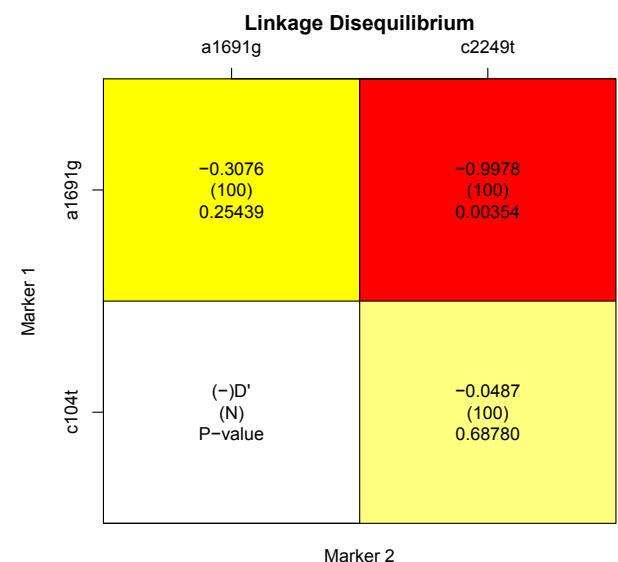

```
> # fit a model
> summary(lm( DELTA.BMI ~
+           homozygote(c104t,'C') +
+           allele.count(a1691g, 'G') +
+           c2249t, data=data))
```

Call:

```
lm(formula = DELTA.BMI ~ homozygote(c104t, "C") +
  allele.count(a1691g, "G") + c2249t,
  data = data)
```

Residuals:

| Min | 1Q | Median | 3Q | Max |
| --- | --- | --- | --- | --- |
| -2.9818 | -0.5917 | -0.0303 | 0.6666 | 2.7101 |

Coefficients:

|  | Estimate | Std. Error |
| --- | --- | --- |
| (Intercept) | -0.1807 | 0.5996 |
| homozygote(c104t, “C”)TRUE | 1.0203 | 0.2290 |
| allele.count(a1691g, “G”) | -0.0905 | 0.1175 |
| c2249tT/C | 0.4291 | 0.6873 |
| c2249tT/T | 0.3476 | 0.5848 |
|  | t value | Pr(>\|t\|) |
| (Intercept) | -0.30 | 0.76 |

```
homozygote(c104t, "C")TRUE    4.46  2.3e-05 ***
allele.count(a1691g, "G")    -0.77     0.44
c2249tT/C                     0.62     0.53
c2249tT/T                     0.59     0.55
---
Signif. codes: 0 '***' 0.001 '**' 0.01
               '*' 0.05 '.' 0.1 ' ' 1

Residual standard error: 1.1 on 95 degrees of
                         freedom
Multiple R-Squared: 0.176,
Adjusted R-squared: 0.141
F-statistic: 5.06 on 4 and 95 DF,
             p-value: 0.000969
```

## Conclusion

The current release of the **genetics** package, 1.0.0, provides a complete set of classes and methods for handling single-locus genetic data as well as functions for computing and testing for departure from Hardy-Weinberg and linkage disequilibrium using a variety of estimators.

As noted earlier, Friedrich Leisch and I collaborated on the design of the data structures. While I was primarily motivated by the desire to provide a natural way to include single-locus genetic variables in statistical models, Fritz also wanted to support multiple genetic changes spread across one or more genes. As of the current version, my goal has largely been realized, but more work is necessary to fully support Fritz’s goal.

In the future I intend to add functions to perform haplotype imputation and generate standard genetics plots.

I would like to thank Friedrich Leisch for his assistance in designing the genotype data structure, David Duffy for contributing the code for the gregarious and HWE.exact functions, and Michael Man for error reports and helpful discussion.

I welcome comments and contributions.